# Aircraft Usage & Maintenance Analysis

#### Interpretation of Sample Autocorrelations & Spectral Density

**Realization:**  
Flight hours display a clear upward trend over the observed period, combined with notable short-term fluctuations. There’s a recurring pattern of increased activity every 2–3 months.

**Spectral Density:**  
Analysis confirms a dominant short-term operating rhythm around every two to three months. Apart from this short cycle, no significant annual or longer-term seasonal patterns are evident. The overall upward trend also strongly influences the spectral profile.

**Takeaway:** expect a 2–3 month operating rhythm; schedule crews and maintenance windows accordingly without assuming fixed annual seasonality.

**Implications for planning**  
Forecasting efforts should prioritize capturing short-term momentum (recent activity trends) and the observed 2–3 month operational rhythm. Long-term planning will benefit from anticipating general growth, but there is limited value in assuming consistent seasonal fluctuations.

### Variable Comparison

#### MX & Flight Hours

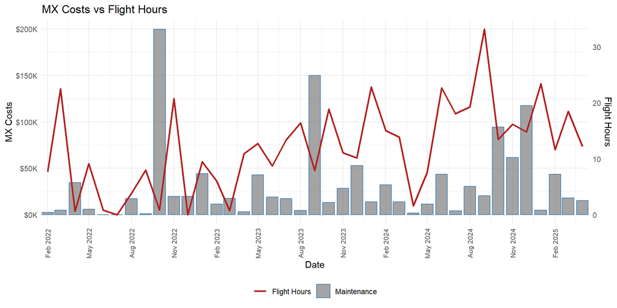

#### Seasonality

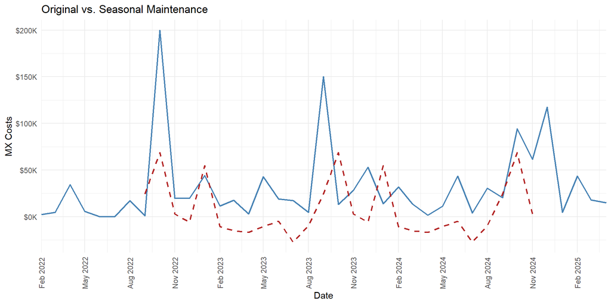

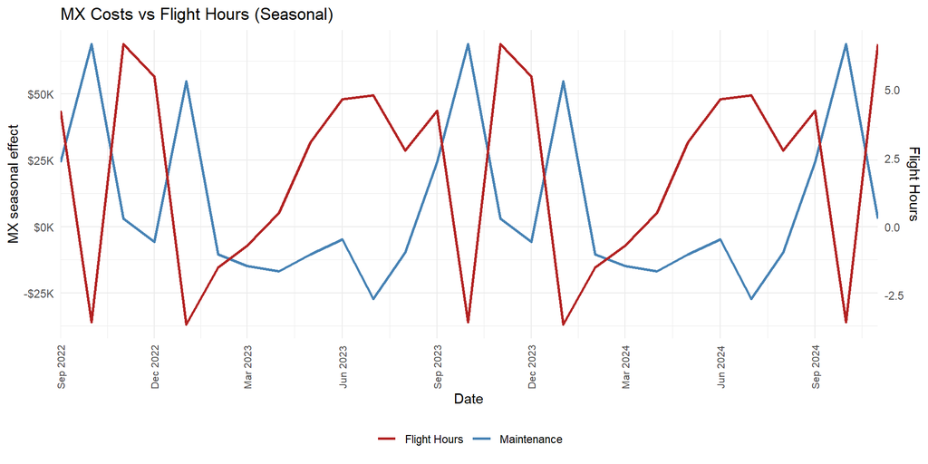

## Vector Autoregression (VAR) Analysis

### Model Selection

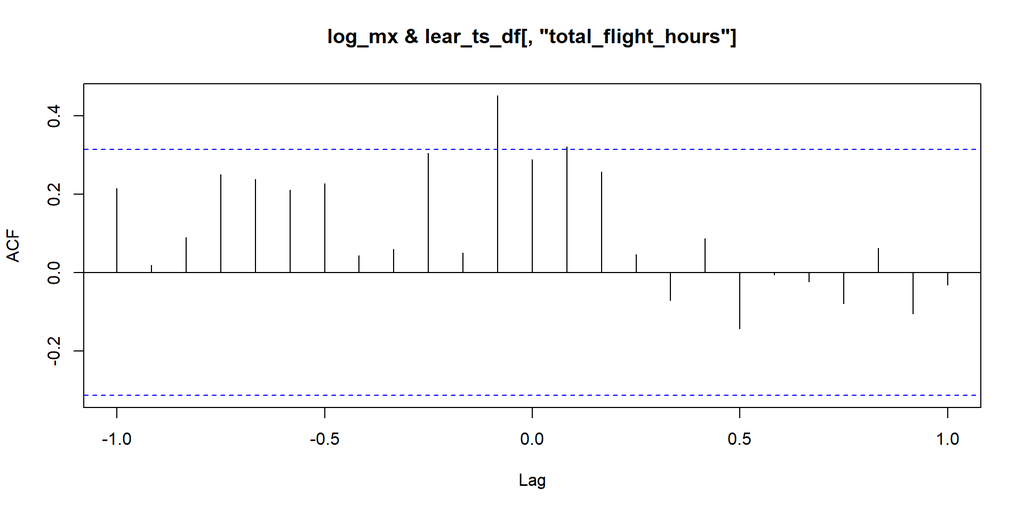

```
[1] "The Raw MX Data is: Stationary (0.05 confidence level)"
```

```
[1] "The Logged MX Data is: Stationary (0.05 confidence level)"
```

```
[1] "The Flight Hour Data is: Non-Stationary(0.05 confidence level)"
```

```
$selection
AIC(n)  HQ(n)  SC(n) FPE(n)
     2      2      2      2

$criteria
                1         2          3         4          5          6
AIC(n)   4.696304  4.440890   4.605817  4.517086   4.553773   4.693837
HQ(n)    4.787400  4.592718   4.818376  4.790376   4.887795   5.088590
SC(n)    4.971129  4.898932   5.247076  5.341562   5.561466   5.884747
FPE(n) 109.662558 85.289540 101.513164 94.466127 100.698249 120.697091
```

```
AIC(n)
     2
```

```
Obs -0.0559953 0.05743237 -0.0002195287 -0.05800009 -0.02860277 0.04934788 -0.04667461 -0.09373548 0.1257871 -0.08495879 0.05817289 -0.03837716
```

```
[1] 0.9904487
```

```
Obs -0.0559953 0.05743237 -0.0002195287 -0.05800009 -0.02860277 0.04934788 -0.04667461 -0.09373548 0.1257871 -0.08495879 0.05817289 -0.03837716 0.1388799 -0.09817328 -0.002972955 -0.02464615 -0.03389081 -0.09437943 0.04736476 -0.04718713 0.05041281 0.1106535 -0.1698417 0.01704277
```

```
[1] 0.9867977
```

### Testing

```
[1] 1.371472
```

```
[1] 39139.36
```

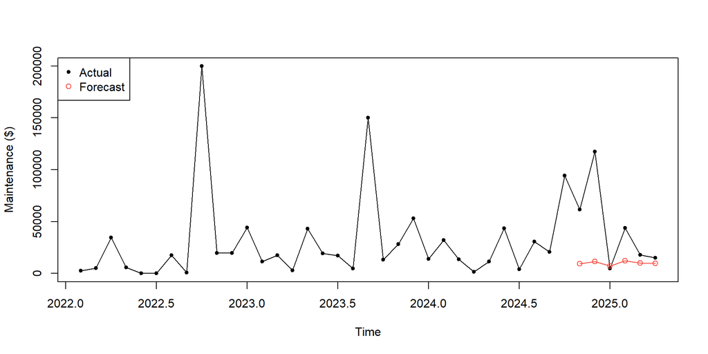

[^2]

### Deployment

*Forecasts are most reliable inside 1–3 months; uncertainty widens beyond that.*

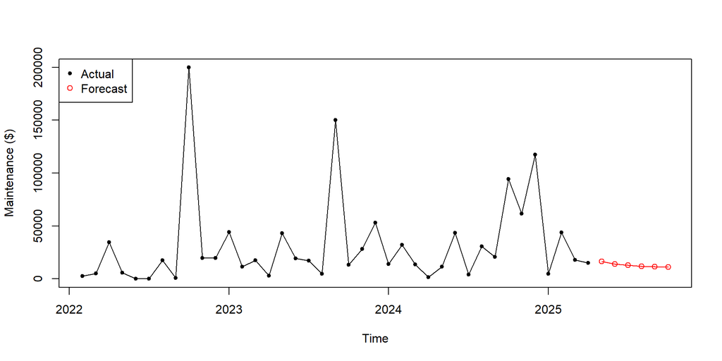

## VARX: Nowcasting Maintenance with Known Same‑Month Flight Hours

### Preface

We receive flight hours for month t about two weeks before maintenance costs for month t are finalized. A standard VAR uses only past values and cannot use those known same-month hours. VARX solves this by keeping **maintenance** as the modeled series and adding **flight hours** (current month plus optional lags) as external inputs. This lets us publish a maintenance nowcast for month t as soon as hours for t are available and uses the 0–2 week information lead on hours.

**Why show VARX next to the baseline VAR** - **VAR:** joint model using lags only. Use when current hours are not yet known. - **VARX:** adds known current hours H_t (and recent lags if helpful). Use when hours arrive first and you need a same-month maintenance nowcast.

**Process** This mirrors the baseline VAR workflow with one change: hours are added as external inputs. Stability checks, constant or trend selection, lag order p, diagnostics, backtesting, and deployment remain the same.

### VARX Model Selection (hours as exogenous)

#### Parts & Labor as Additional Endogenous Variables

Because VAR works with at least 2 endogenous variables, and because we are turning Flight Hours into a exogenous variables for the purpose of maintaining more realistic modeling expectations of the flow and delivery sequences of the data, we will include two additional variables in additional to Total Maintenance. These are Parts & Labor, which are sub-costs of Total Maintenance. In addition to improving the functionality of the model, these variables may also prove to explain additional makeup of the analyses and forecasts.

```
Obs -0.06828613 0.02283816 -0.5762611 0.1062506 -0.1892963 0.2425002 0.06692879 0.07569532 -0.18475 -0.02136321 0.1749941 0.08219499
Obs 0.08569292 -0.120323 -0.399761 -0.1626059 0.08841484 0.1049501 0.06613789 -0.1645064 0.09025442 0.1162779 0.1240922 -0.1271671
Obs 0.02288215 0.02716222 -0.3161546 -0.1418211 0.001493391 0.05615 -0.1000505 0.04240034 0.09595192 0.09397556 -0.01223425 -0.1231971
```

```
Obs -0.06828613 0.02283816 -0.5762611 0.1062506 -0.1892963 0.2425002 0.06692879 0.07569532 -0.18475 -0.02136321 0.1749941 0.08219499 -0.09903023 -0.3047305 0.03991742 0.03748895 0.2452704 -0.0174516 0.1669807 -0.2917149 -0.01725554 -0.1851549 0.2151575 -0.1039344
Obs 0.08569292 -0.120323 -0.399761 -0.1626059 0.08841484 0.1049501 0.06613789 -0.1645064 0.09025442 0.1162779 0.1240922 -0.1271671 -0.2848903 -0.181239 0.0008364903 0.2731182 0.1502731 -0.07783704 -0.01122785 -0.1007073 0.01122461 -0.02545393 0.08423216 -0.06220584
Obs 0.02288215 0.02716222 -0.3161546 -0.1418211 0.001493391 0.05615 -0.1000505 0.04240034 0.09595192 0.09397556 -0.01223425 -0.1231971 -0.2478924 -0.1070904 -0.1019867 0.1346825 0.1253769 0.07901887 -0.02679119 -0.04978716 0.01506201 -0.03808515 0.09151693 -0.02117352
```

### VARX Backtest on a Split (uses realized hours as exogenous path)

When hours for month t are known, build `X_future` with H_t and its lags ($H_{t−1}, H_{t−2}$).

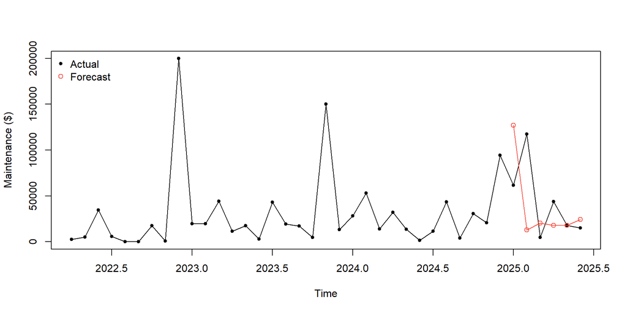

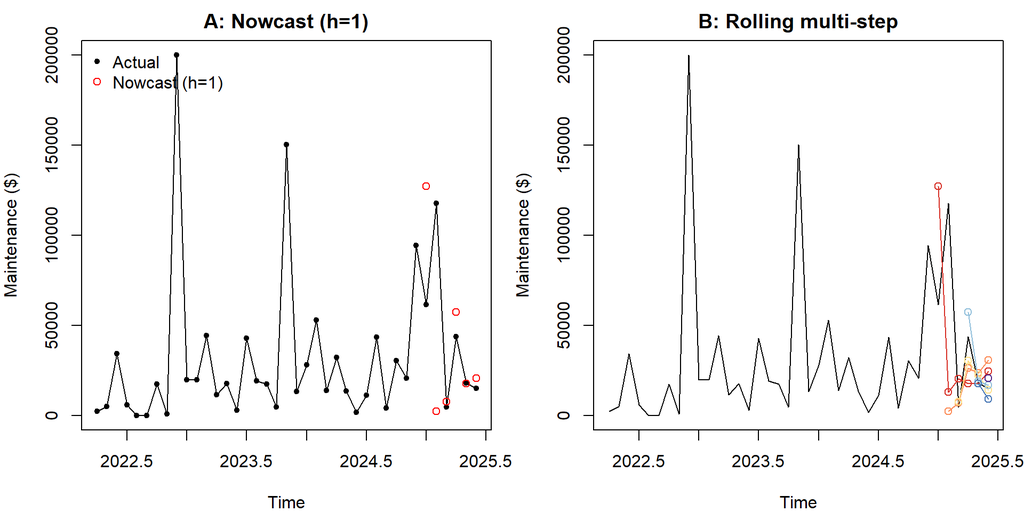

### Deployment (full re‑fit) and multi‑step forecasts

For horizons >1, you must provide an **exogenous path** for hours: - **Nowcast** (h=1): use known H_t and known lags. - **Short‑term forecast** (h>1): provide hour scenarios or forecast hours in a separate model and pass them via `dumvar`.

#### Flight Hours

```
              H_t       L1       L2
used     9.686683 16.44156 20.74753
expected 9.000000 16.44156 20.74753
```

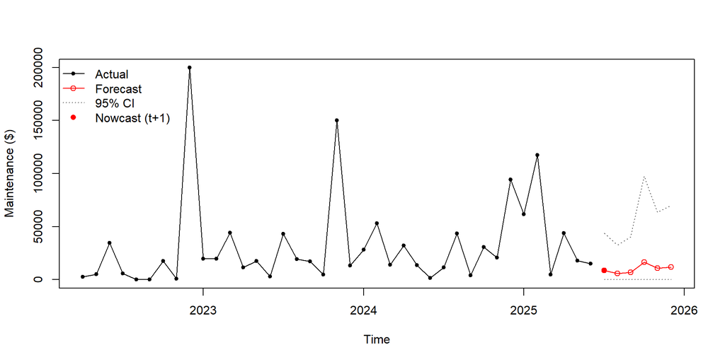

## Footnotes

[^1]: Monthly data; last 6 months held out for testing; forecasts shown in original units after any transformations.
[^2]: Monthly data; last 6 months held out for testing; forecasts shown in original units after any transformations.